# Relation between Products

David and Fabi

11/12/2019

## SUMMARY

In this report we have worked to fulfil Blackwell’s needs of understanding of Electronidex Clientele and to assess a potential adquisition .

Electronidex is a start-ip electronics online retailer, which has politely provided us with a CSV file containing 1 month of transactions and also with a portfolio of their current available products, all this provided despite its lack of funding and means.

For this purpose, our team has carried out a market basket analysis in order to find insightful information, among it we hope to find patterns and items relationships, but also to build recommendations based on the results found.

## Data Exploration

The provided dataset was imported as a transactions file, then we used the portfolio file to assign their respective categories to the 125 products. For a deeper analysis, the data was split in 2 classes. On this analysis we have make a costumer segmentacion for B2B clients and B2C clients.

Data provided is only for 1 month of transactions, it would be interesting to know what month or season is, to understand better the transactions. E.g. We can get confused classifying B2B and B2C during Christmas or Black Friday.

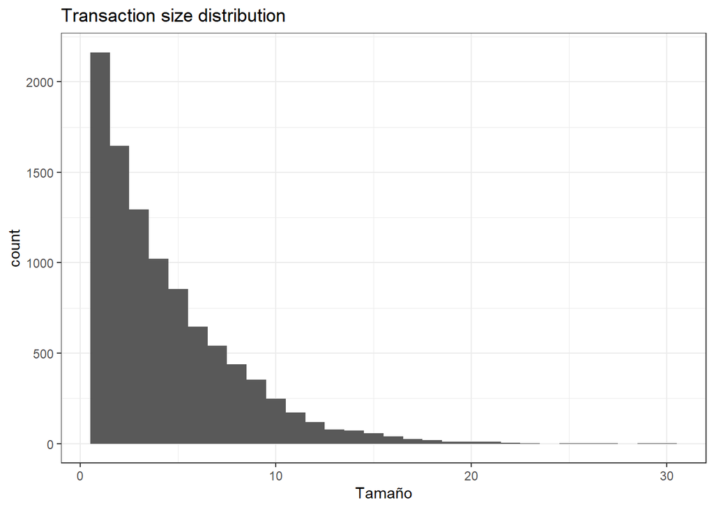

## B2B AND B2C CLIENTES

To take in consideration the items most frequent we have also to consider the support.

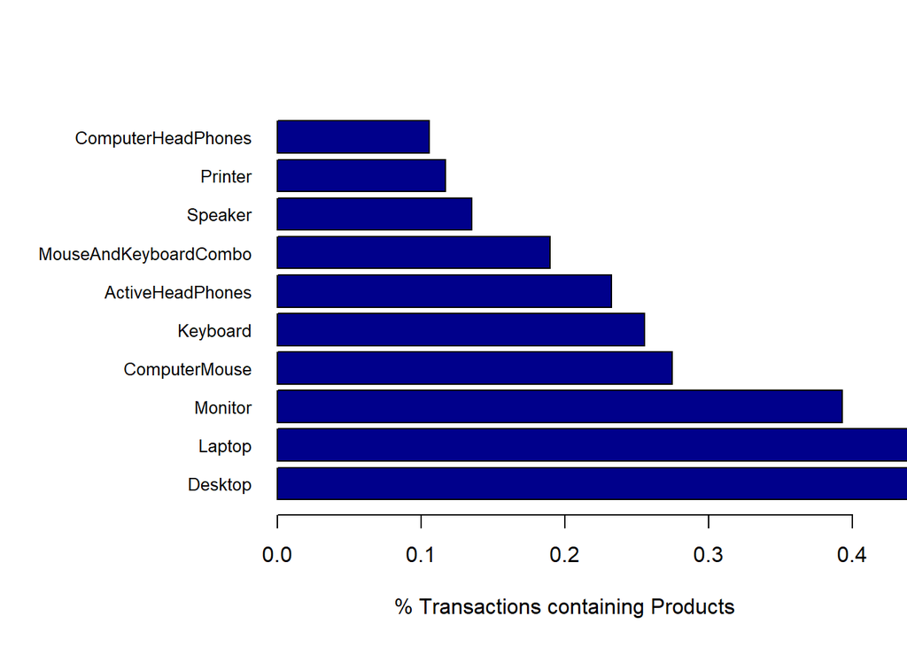

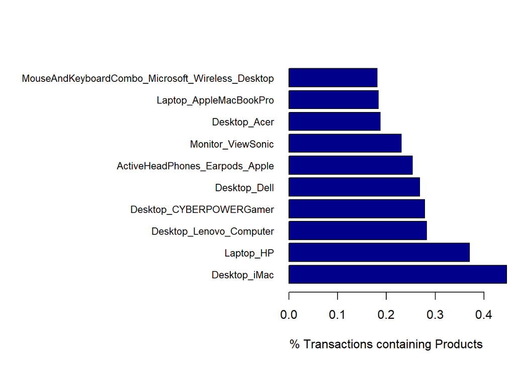

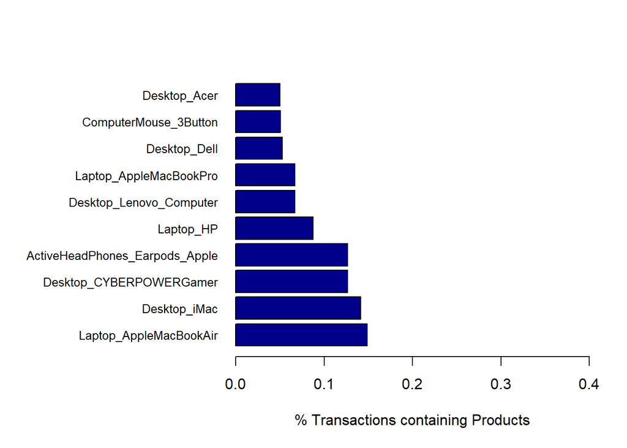

## MARKET BASKET ANALYSIS

Despite being a start-up, Electronidex seems to have already a B2B clientes, and also a B2C clientes for high end products. Most sold products are Desktops and Laptops, which are the most profitable products. Weaknesses have been detected, but can be easily solved by Blackwell right after the purchasing.

Electronidex B2C most sold products are high end, while Blackwell not. Blackwell could use this to have 2 brands depending on the target customer, this is very useful to access the full customer spectre.

For this analysis, we have used a support of 0.025 and a confidence level of 0.1. For the B2C and B2B we have obtained 10 rules.

Printer ink is one of the least sold products, even when it should be more sold than printers, meaning that there is room to improve, specially having such a big B2B ratio.

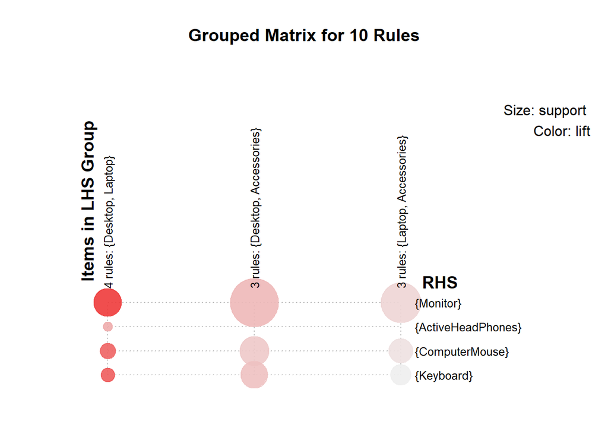

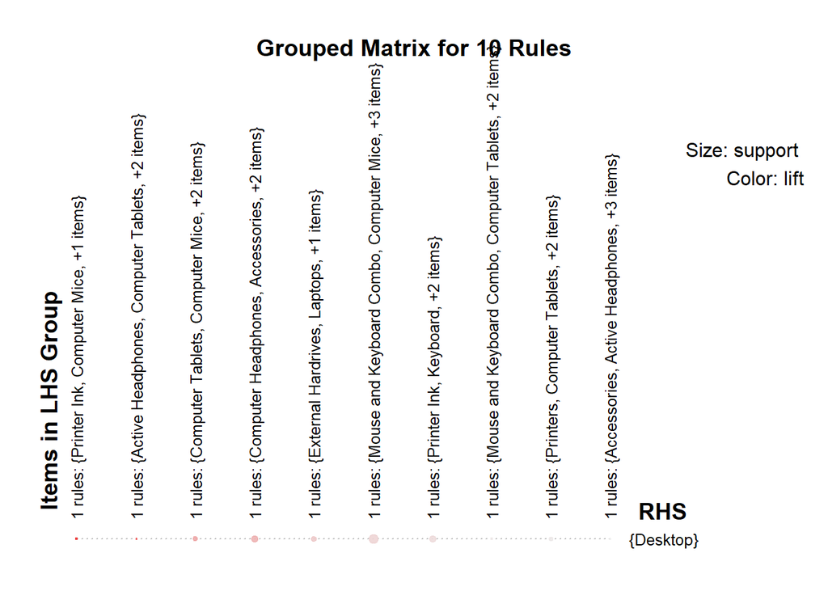

## CONCLUSIONS AND RECOMMENDATIONS

Aside of the previously mentioned in this report, we got to the following conclusions and recommendations:

Based on the previous analysis we know that Blackwell’s offers a Extended Warranty service while Electronidex does not. This lowers Electronidex value but we can apply Blackwell’s strenght to cover it and make Eletronidex more valuable after the purchase.

Electronidex is only able to pull data on the items that customers purchased per their transactions" While this fact has limited our chances to analize deeper the company, also points out that there is a lot of room for improvement, therefore increase Electronidex’s value after its purchase.

Many rules could be considered irrelevant, but for these, we could suggest to the customer the products with more added value, since we may not affect customer’s decision of buying an specific accessory, but we can push him/her to buy a better one (more added value). E.g. Laptop + gaming mouse instead of a regular mouse.

We can either suggest a high added value product, or a medium related product, so customer buys what they weren’t looking for. For this, we could select products we want to promote.

Related to the previous points: Bundles with low sales products could be offer while navigating to promote them (for selected ones), so “you buy what you weren’t looking for”. Bundles for highly related products could be offered right before the purchase step, to provoke a last impulse to buy it, "You forgot to buy x?

We shouldn’t focus only on highly related products, since we want to promote the medium ones (we could identify future trends!)

We have found interesting baskets -> Not apparently related products (Dell + apple keyboard)

Blackwell’s purchasing power can help Electronidex get better deals with producers and distributors, finally improving their sales via cheaper prices.

Despite being a start-up, Electronidex seems to have already a B2B clientes, and also a B2C clientes for high end products. Most sold products are Desktops and Laptops, which are the most profitable products. Weaknesses have been detected, but can be easily solved by Blackwell right after the purchasing.

Therefore, based on this analysis, we support the purchasing of Electronidex, and hope that this reports, among the other proper analysis, enlights this decision taking.

As limitations we can conclude that:

Electronidex is only able to pull data on the items that customers purchased per their transactions" More info could have been provided.

No economic info, eg Price, profict margin, amount spent per transaction, etc. It would be easier to classify per B2B with this info. We have not been provided with Blackwell’s transactions, to understand how different clientele is.